# Homework 4

Samikshya

2022-10-22

## Homework 4: Bootstrap Testing

Notebook by: Samikshya Pandey ## Question 5.7 a. Some of the reasons why there could be less sample when there was male experimenter could be because the male skateboarders might not feel comfortable in having their tests taken through saliva. The day could have been less sunny or could be on holiday because of which the sample in itself was small. Because we dont have more information about the sample and other surrounding factors, we could be missing key variables that could impact the sample and their behaviours thus threatening the randomness of the sample.

2. It was important that the two experimenters were blinded to the purpose of the story because first, the skateborders might react differently if they knew that their testosterone level were being measured. If they knew that this was being measured against the presence of men or female experimenter could affect their behavior and thus the data collected could be biased. Similarly, if both experimenter male and female knew the hypothesis test than they could employ their inherent bias and thus they may not be able to capture the true behaviors of the skateborders.

## Question 5.8

1. Mean of the sample would be distribution would be 36 and the SD would be 8.

```r
sample.distrubtion.std = 8/sqrt(200)
```

```r
library (tidyverse)
```

```r
library (ggplot2)
library (resampledata)
library (dplyr)
```

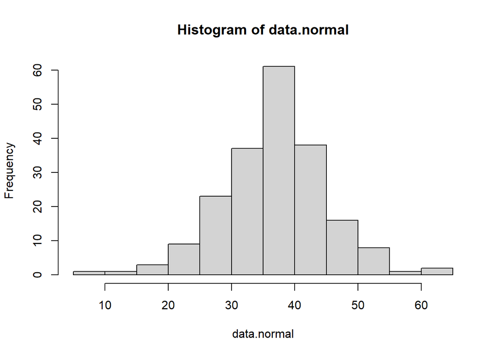

```r
set.seed(10000)
data.normal <- rnorm ( n = 200, mean  = 36, sd = 8)
hist(data.normal)
```

The sample size of 200 also has a normal distribution centered around 36. The mean is 36.6889 and standard error is 8.077

```r
mean.sample <- mean(data.normal)
mean.sample
```

```
## [1] 36.6889
```

```r
std.sample <- sd(data.normal)
std.sample
```

```
## [1] 8.077715
```

```r
n <- 200 #The number of the sample we want in the bootstrap
N <- 10^4 #Number of times we want the simulation to run

mean.bootstrapsample <- numeric(N)

for (i in 1:N)
{
  bootstrapdata <- sample(data.normal, n, replace = TRUE) #our sample is 200, we are using the dataset we got earlier and replace is true because it is bootstrap.
  mean.bootstrapsample[i] = mean(bootstrapdata)
}
```

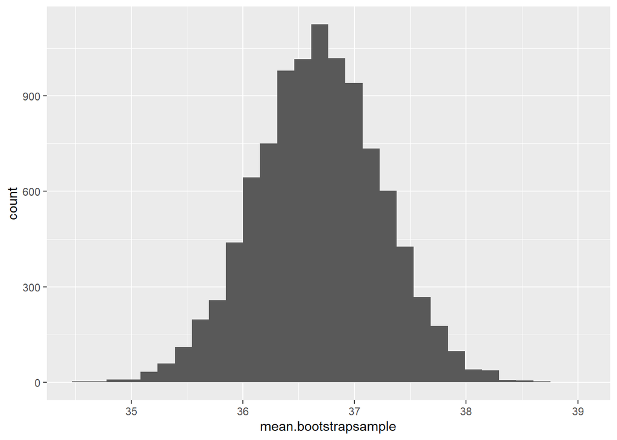

```r
ggplot(data = tibble(mean.bootstrapsample), mapping = aes(x = mean.bootstrapsample)) +
geom_histogram()
```

```r
mean.bootstrap <- mean(mean.bootstrapsample)
standardeviation.bootstrap <- sd(mean.bootstrapsample)
```

The mean of the bootstrap sample is 36.679. It is centered around the sample from which the bootstrap sample was drawn and the standard error is 0.564 because of the large N times the data was run.

```r
dataset.table <-matrix(c(36, 8, 36, sample.distrubtion.std, mean.sample, std.sample, mean.bootstrap, standardeviation.bootstrap), ncol =2, byrow = TRUE )
colnames(dataset.table) <- c("Mean", "Standard Deviation")
rownames(dataset.table)<- c("Population", "Sampling Distribution (Theoritical)", "Sample", "Bootstrap distribution")
dataset.table <- as.table(dataset.table)
dataset.table
```

```
##                                           Mean Standard Deviation
## Population                          36.0000000          8.0000000
## Sampling Distribution (Theoritical) 36.0000000          0.5656854
## Sample                              36.6889029          8.0777150
## Bootstrap distribution              36.6790630          0.5647565
```

###For n = 50

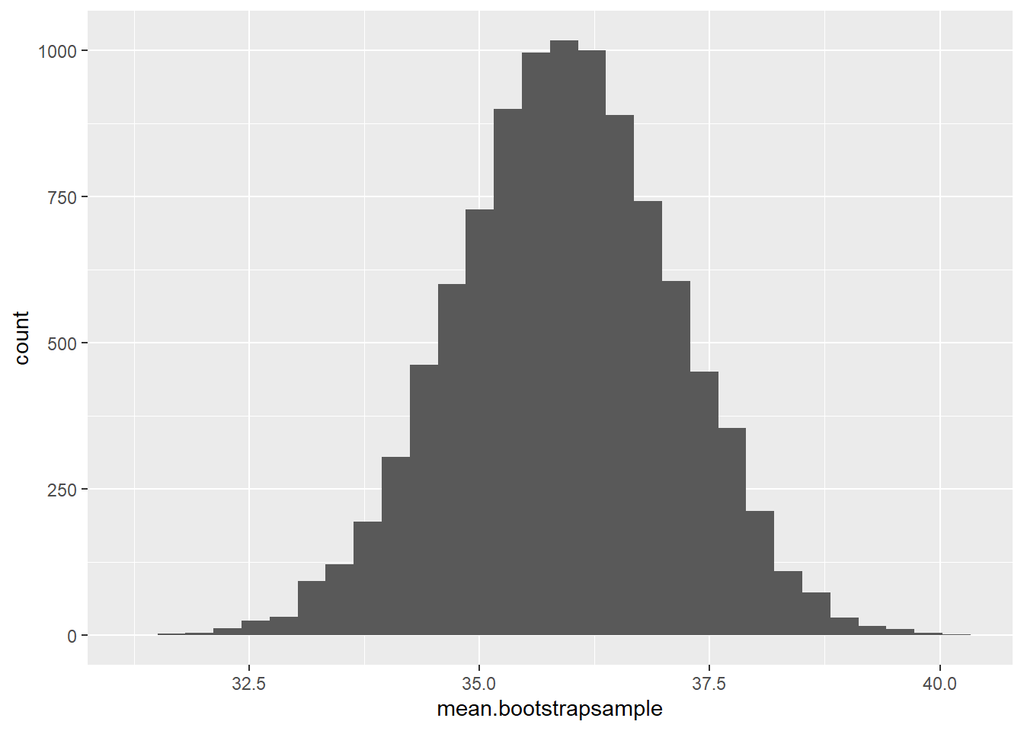

```r
data.normal.50 <- rnorm(n =50 ,mean  = 36, sd = 8)

n <- 50 #The number of the sample we want in the bootstrap
N <- 10^4 #Number of times we want the simulation to run

mean.bootstrapsample <- numeric(N)

for (i in 1:N)
{
  bootstrapdata <- sample(data.normal.50, n, replace = TRUE) #our sample is 200, we are using the dataset we got earlier and replace is true because it is bootstrap.
  mean.bootstrapsample[i] = mean(bootstrapdata)
}
ggplot(data = tibble(mean.bootstrapsample), mapping = aes(x = mean.bootstrapsample)) +
geom_histogram()
```

```r
mean.bootstrap.50 <- mean(mean.bootstrapsample)
standardeviation.bootstrap.50 <- sd(mean.bootstrapsample)
mean.bootstrap.50
```

```
## [1] 35.91911
```

```r
standardeviation.bootstrap.50
```

```
## [1] 1.189417
```

###for n = 10

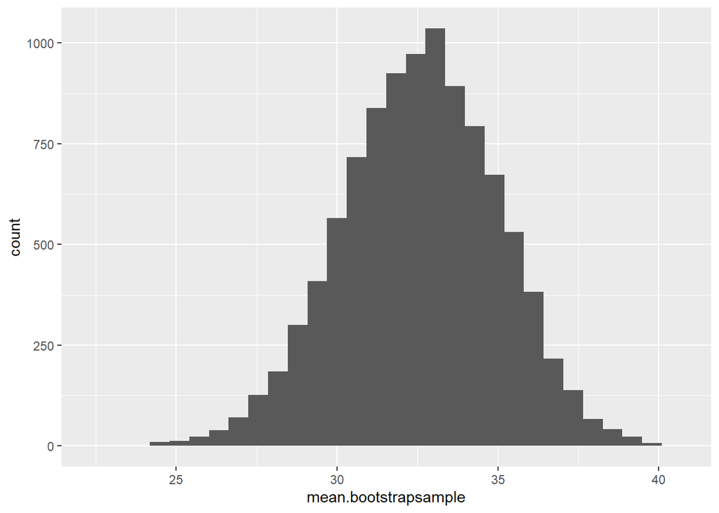

```r
data.normal.10 <- rnorm(n =10 ,mean  = 36, sd = 8)
n <- 10 #The number of the sample we want in the bootstrap
N <- 10^4 #Number of times we want the simulation to run

mean.bootstrapsample <- numeric(N)

for (i in 1:N)
{
  bootstrapdata <- sample(data.normal.10, n, replace = TRUE) #our sample is 200, we are using the dataset we got earlier and replace is true because it is bootstrap.
  mean.bootstrapsample[i] = mean(bootstrapdata)
}
ggplot(data = tibble(mean.bootstrapsample), mapping = aes(x = mean.bootstrapsample)) +
geom_histogram()
```

```r
mean.bootstrap.10 <- mean(mean.bootstrapsample)
standardeviation.bootstrap.10 <- sd(mean.bootstrapsample)
mean.bootstrap.10
```

```
## [1] 32.57127
```

```r
standardeviation.bootstrap.10
```

```
## [1] 2.41559
```

```r
dataset.table.final <-matrix(c(36, 8, 36, sample.distrubtion.std, mean.sample, std.sample, mean.bootstrap, standardeviation.bootstrap, mean.bootstrap.50, standardeviation.bootstrap.50, mean.bootstrap.10,
standardeviation.bootstrap.10), ncol =2, byrow = TRUE )
colnames(dataset.table.final) <- c("Mean", "Standard Deviation")
rownames(dataset.table.final)<- c("Population", "Sampling Distribution", "Sample", "Bootstrap distribution 200","Bootstrap distribution 50","Bootstrap distribution 10")
dataset.table.final <- as.table(dataset.table.final)
dataset.table.final
```

```
##                                  Mean Standard Deviation
## Population                 36.0000000          8.0000000
## Sampling Distribution      36.0000000          0.5656854
## Sample                     36.6889029          8.0777150
## Bootstrap distribution 200 36.6790630          0.5647565
## Bootstrap distribution 50  35.9191075          1.1894172
## Bootstrap distribution 10  32.5712743          2.4155904
```

The mean regardless of the sample size tends to center around the sample mean (36) however, the standard deviation/standard error decreases as the number of sample increases in the bootstrap distribution. When n is really small (i.e in case of n =10), even in normal distribution, the bootstrap mean is different that both sample distribution as well as population mean.

## Question 5.9

```r
population.mean.gamma <- 5/(1/4)
population.sd.gamma <- sqrt(5/(1/4)^2)
population.mean.gamma
```

```
## [1] 20
```

```r
population.sd.gamma
```

```
## [1] 8.944272
```

1. We need to run the for loop because we dont know how the smapling distribution will behave under gamma distribution. We didnt need to do this for 5.8 because we know that the sampling distribution for normal behaves like a normal distribution. To check the sample mean and SD, we need to run the simulation 200 times like mentioned in the question.

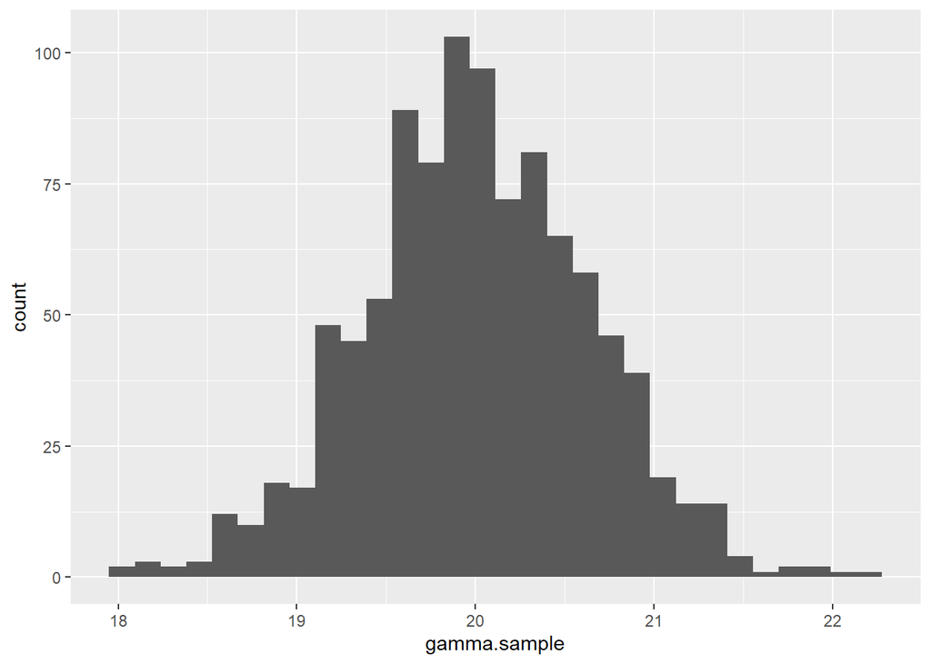

```r
#Drawing a sample from above distribution:
set.seed(1000)
gamma.sample <- numeric(1000)

for (j in 1: 1000)
{
  a <- rgamma(n=200, shape =  5, rate =  0.25)
  gamma.sample[j] = mean(a)
}

ggplot(data = tibble(gamma.sample), mapping = aes(x = gamma.sample)) +
geom_histogram()
```

The distribution of the samples of the gamma distribution is normally distributed with mean of 20.00 and standard error of 0.63687

```r
mean.sample.gamma = mean(gamma.sample)
std.sample.gamma = sd(gamma.sample)
mean.sample.gamma
```

```
## [1] 20.00617
```

```r
std.sample.gamma
```

```
## [1] 0.6368764
```

```r
sample.gamma <- rgamma(n=200, shape =  5, rate =  0.25)

sample.gamma.mean = mean(sample.gamma)
sample.gamma.sd <- sd(sample.gamma)
```

```r
N <- 10^4
sample.size = 200
gamma.bootstrap.mean <- numeric(N)

for (i in 1:N)
{
  gamma.bootstrap <- sample(sample.gamma, size =sample.size, replace = TRUE)
  gamma.bootstrap.mean[i] <- mean(gamma.bootstrap)
}
```

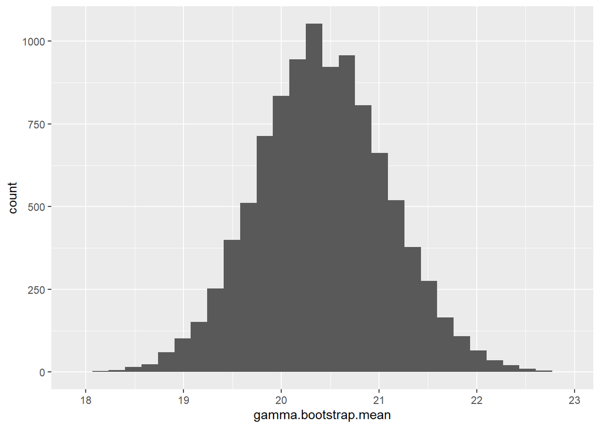

```r
ggplot(data = tibble(gamma.bootstrap.mean), mapping = aes(x = gamma.bootstrap.mean)) +
geom_histogram()
```

```r
mean.gamma.bootstrap200 <- mean(gamma.bootstrap.mean)
std.gamma.bootstrap200 <-sd(gamma.bootstrap.mean)
mean.gamma.bootstrap200
```

```
## [1] 20.42178
```

```r
std.gamma.bootstrap200
```

```
## [1] 0.6666698
```

```r
dataset.table.gamma <-matrix(c(population.mean.gamma,population.sd.gamma, mean.sample.gamma, std.sample.gamma,sample.gamma.mean, sample.gamma.sd, mean.gamma.bootstrap200, std.gamma.bootstrap200), ncol =2, byrow = TRUE)
colnames(dataset.table.gamma) <- c("Mean", "Standard Deviation")
rownames(dataset.table.gamma)<- c("Population","Sampling Distribution", "Sample", "Bootstrap distribution")
dataset.table.gamma <- as.table(dataset.table.gamma)
dataset.table.gamma
```

```
##                              Mean Standard Deviation
## Population             20.0000000          8.9442719
## Sampling Distribution  20.0061681          0.6368764
## Sample                 20.4190001          9.4695107
## Bootstrap distribution 20.4217843          0.6666698
```

The mean is centered around 20. The mean of sample we took and bootstrap distribution is very close. however, the standard deviation/error decreases in bootstrap distribution and is very similar to the sampling distribution. The SD of population and sample is very close as well.

```r
sample.gamma.50 <- rgamma(n=50, shape =  5, rate =  0.25)

N <- 10^4
sample.size = 50
gamma.bootstrap.mean <- numeric(N)

for (i in 1:N)
{
  gamma.bootstrap <- sample(sample.gamma.50, size =sample.size, replace = TRUE)
  gamma.bootstrap.mean[i] <- mean(gamma.bootstrap)
}

head(gamma.bootstrap.mean)
```

```
## [1] 18.64768 18.10851 19.70091 18.41671 20.08181 18.89169
```

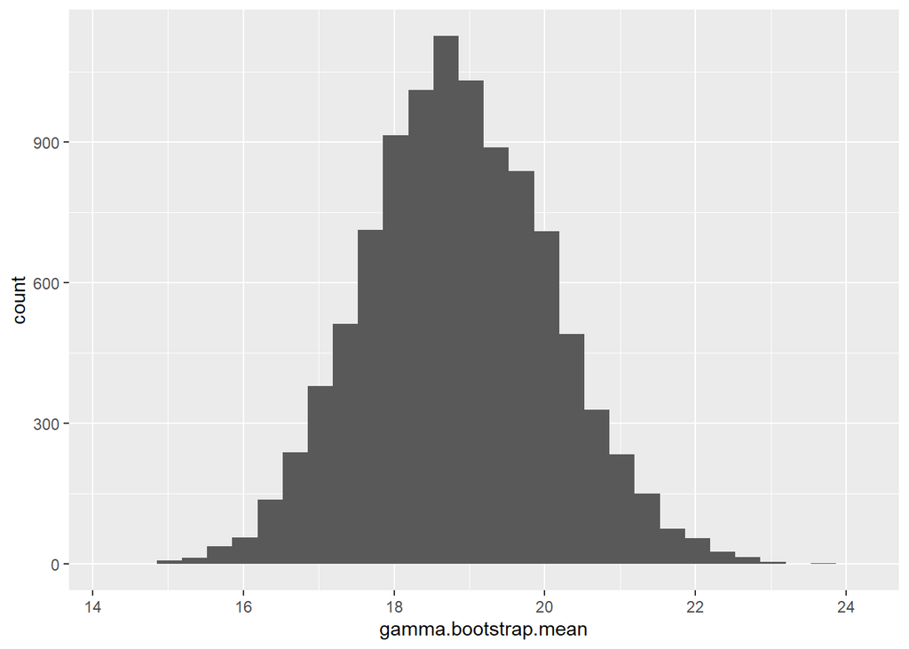

```r
ggplot(data = tibble(gamma.bootstrap.mean), mapping = aes(x = gamma.bootstrap.mean)) +
geom_histogram()
```

```r
mean.gamma.bootstrap50 <- mean(gamma.bootstrap.mean)
std.gamma.bootstrap50 <-sd(gamma.bootstrap.mean)
mean.gamma.bootstrap50
```

```
## [1] 18.85478
```

```r
std.gamma.bootstrap50
```

```
## [1] 1.238081
```

##FOr 10

```r
gamma.sample.10 <- rgamma(n=50, shape =  5, rate =  0.25)
N <- 10^4
sample.size = 10
gamma.bootstrap.mean <- numeric(N)

for (i in 1:N)
{
  gamma.bootstrap <- sample(gamma.sample.10, size =sample.size, replace = TRUE)
  gamma.bootstrap.mean[i] <- mean(gamma.bootstrap)
}

head(gamma.bootstrap.mean)
```

```
## [1] 19.50694 26.65946 22.53423 19.33909 22.48802 21.05897
```

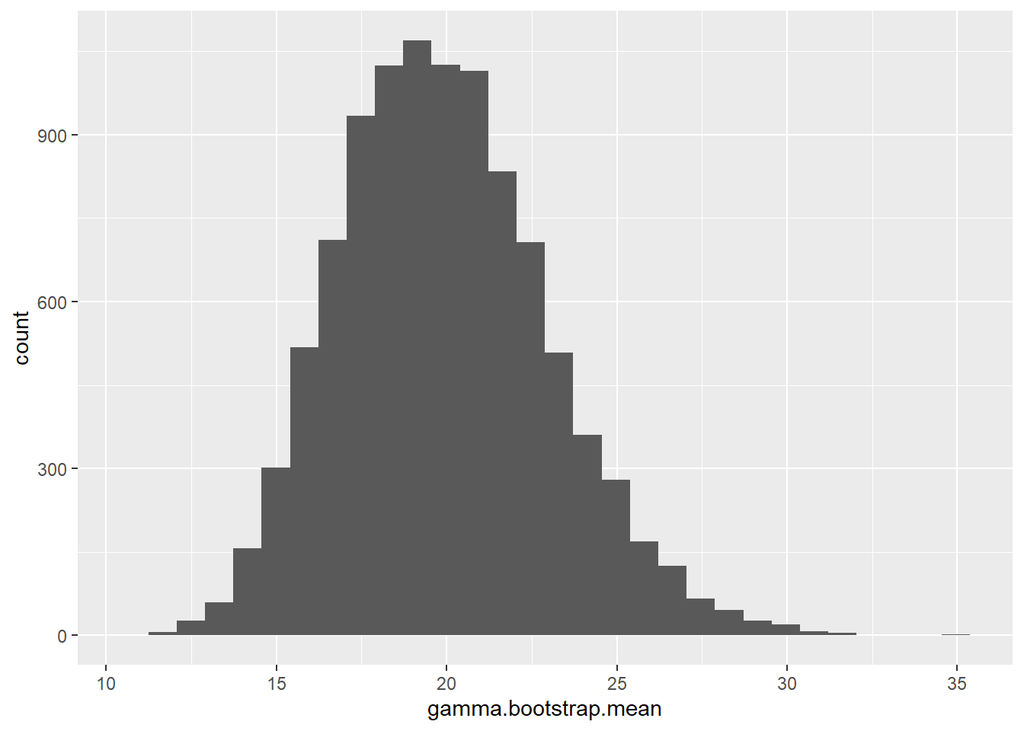

```r
ggplot(data = tibble(gamma.bootstrap.mean), mapping = aes(x = gamma.bootstrap.mean)) +
geom_histogram()
```

```r
mean.gamma.bootstrap10 <- mean(gamma.bootstrap.mean)
std.gamma.bootstrap10 <-sd(gamma.bootstrap.mean)
mean.gamma.bootstrap10
```

```
## [1] 19.91252
```

```r
std.gamma.bootstrap10
```

```
## [1] 3.059359
```

```r
dataset.table.gamma.final <-matrix(c(population.mean.gamma,population.sd.gamma, mean.sample.gamma, std.sample.gamma,sample.gamma.mean, sample.gamma.sd, mean.gamma.bootstrap200, std.gamma.bootstrap200, mean.gamma.bootstrap50, std.gamma.bootstrap50,mean.gamma.bootstrap10, std.gamma.bootstrap10), ncol =2, byrow = TRUE)
colnames(dataset.table.gamma.final) <- c("Mean", "Standard Deviation")
rownames(dataset.table.gamma.final)<- c("Population","Sampling Distribution", "Sample", "Bootstrap distribution200", "Bootstrap distribution50","Bootstrap distribution10")
dataset.table.gamma.final <- as.table(dataset.table.gamma.final)
dataset.table.gamma.final
```

```
##                                 Mean Standard Deviation
## Population                20.0000000          8.9442719
## Sampling Distribution     20.0061681          0.6368764
## Sample                    20.4190001          9.4695107
## Bootstrap distribution200 20.4217843          0.6666698
## Bootstrap distribution50  18.8547785          1.2380813
## Bootstrap distribution10  19.9125213          3.0593592
```

## Question 5.10

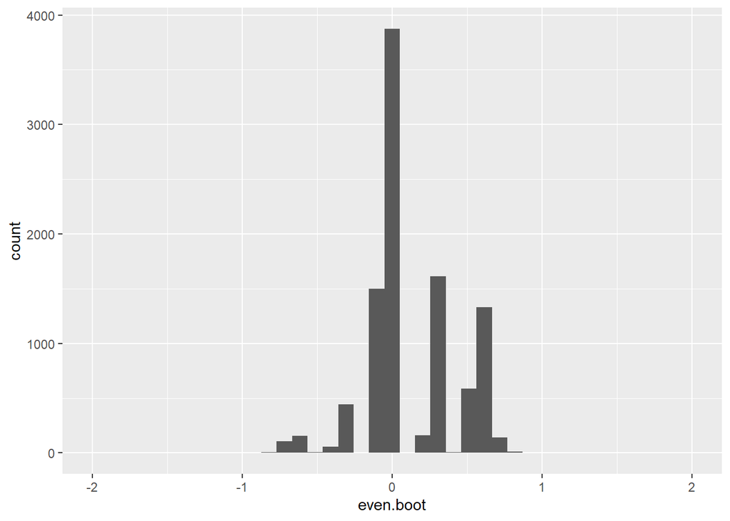

```r
ne <- 14 # n even
no <- 15 # n odd
wwe <- rnorm(ne) # draw random sample of size ne
wwo <- rnorm(no) # draw random sample of size no
N <- 10^4
even.boot <- numeric(N) # save space
odd.boot <- numeric(N)
for (i in 1:N)
{
x.even <- sample(wwe, ne, replace = TRUE)
x.odd <- sample(wwo, no, replace = TRUE)
even.boot[i] <- median(x.even)
odd.boot[i] <- median(x.odd)
}

par(mfrow = c(2,1))
# set figure layout
ggplot(data = tibble(even.boot), mapping = aes(x = even.boot))+
  geom_histogram(bins = 40)+
  xlim(-2,2)
```

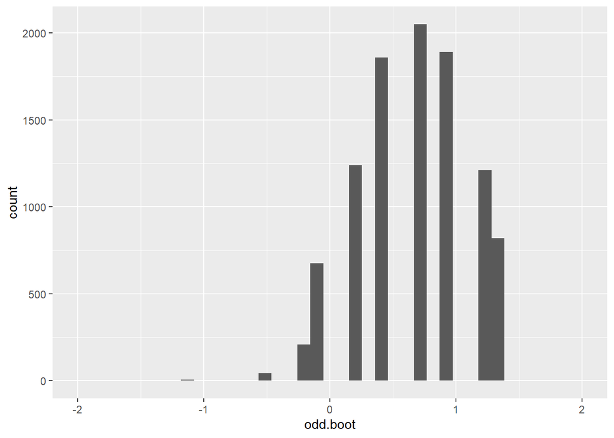

```r
ggplot(data = tibble(odd.boot), mapping = aes(x = odd.boot))+
  geom_histogram(bins = 40)+
  xlim(-2,2)
```

```r
par(mfrow = c(1,1))
```

```r
median.even <- median(even.boot)
std.even<- sd(even.boot)
median.odd <- median(odd.boot)
std.odd <- sd(odd.boot)
```

Changing the sample size to 36 and 37

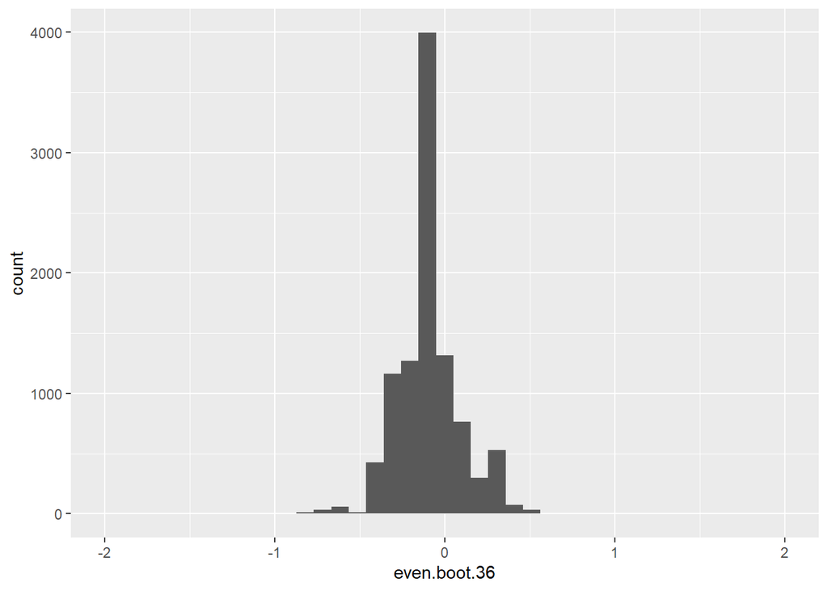

```r
ne <- 36 # n even
no <- 37 # n odd
wwe <- rnorm(ne) # draw random sample of size ne
wwo <- rnorm(no) # draw random sample of size no
N <- 10^4
even.boot.36 <- numeric(N) # save space
odd.boot.37 <- numeric(N)
for (i in 1:N)
{
x.even <- sample(wwe, ne, replace = TRUE)
x.odd <- sample(wwo, no, replace = TRUE)
even.boot.36[i] <- median(x.even)
odd.boot.37[i] <- median(x.odd)
}

par(mfrow = c(2,1))
# set figure layout
ggplot(data = tibble(even.boot.36), mapping = aes(x = even.boot.36))+
  geom_histogram(bins = 40)+
  xlim(-2,2)
```

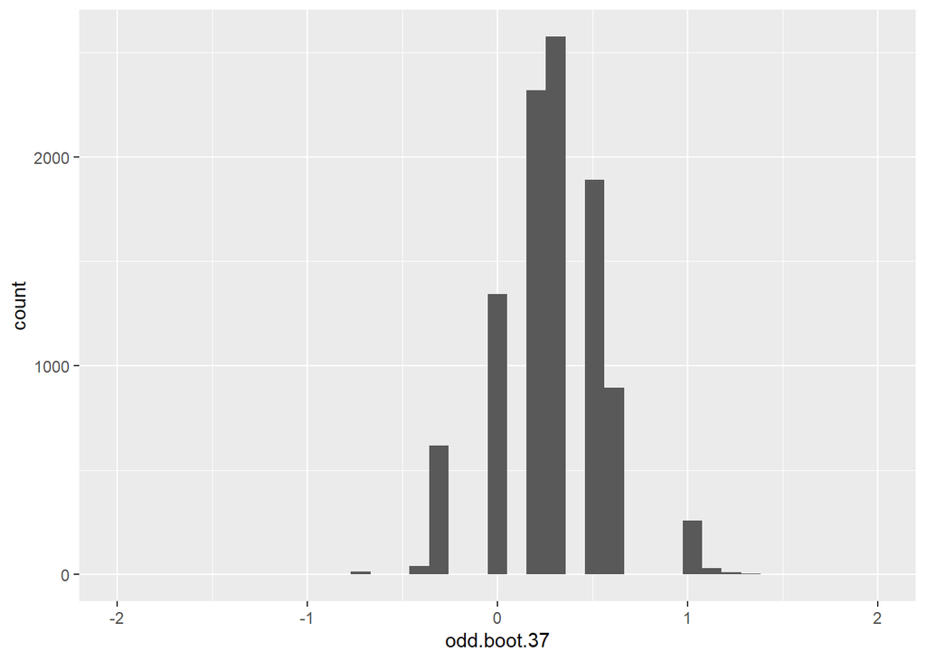

```r
ggplot(data = tibble(odd.boot.37), mapping = aes(x = odd.boot.37))+
  geom_histogram(bins = 40)+
  xlim(-2,2)
```

```r
par(mfrow = c(1,1))
```

```r
median.even.36 <- median(even.boot.36)
std.even.36<- sd(even.boot.36)
median.odd.37 <- median(odd.boot.37)
std.odd.37 <- sd(odd.boot.37)
```

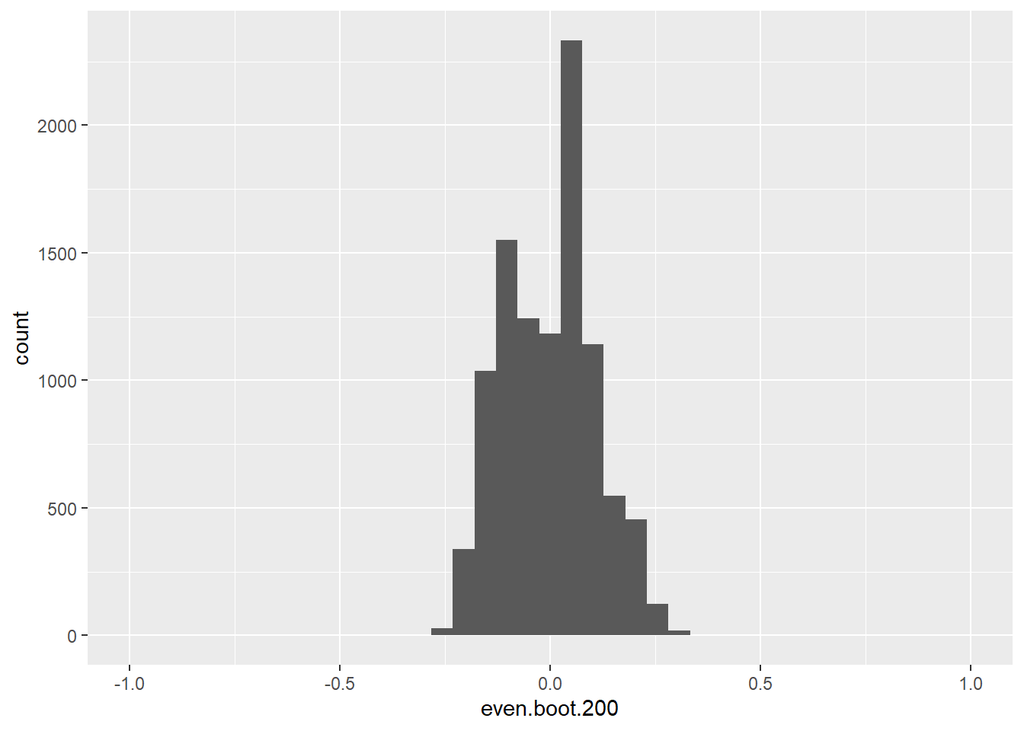

```r
ne <- 200 # n even
no <-201 # n odd
wwe <- rnorm(ne) # draw random sample of size ne
wwo <- rnorm(no) # draw random sample of size no
N <- 10^4
even.boot.200 <- numeric(N) # save space
odd.boot.201 <- numeric(N)
for (i in 1:N)
{
x.even <- sample(wwe, ne, replace = TRUE)
x.odd <- sample(wwo, no, replace = TRUE)
even.boot.200[i] <- median(x.even)
odd.boot.201[i] <- median(x.odd)
}

par(mfrow = c(2,1))
# set figure layout
ggplot(data = tibble(even.boot.200), mapping = aes(x = even.boot.200))+
  geom_histogram(bins = 40)+
  xlim(-1,1)
```

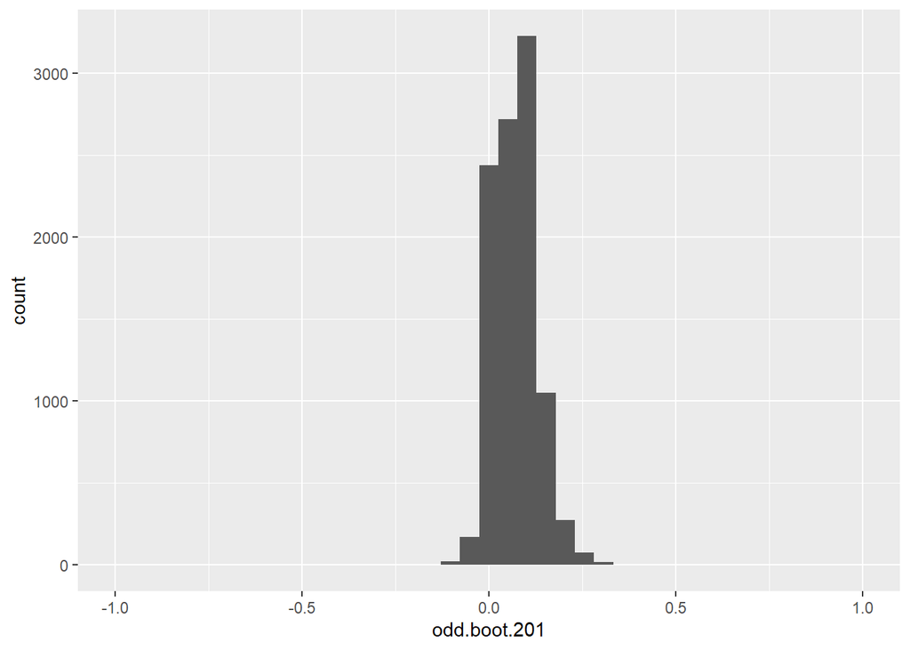

```r
ggplot(data = tibble(odd.boot.201), mapping = aes(x = odd.boot.201))+
  geom_histogram(bins = 40)+
  xlim(-1,1)
```

```r
par(mfrow = c(1,1))
```

```r
median.even.200 <- median(even.boot.200)
std.even.200<- sd(even.boot.200)
median.odd.201 <- median(odd.boot.201)
std.odd.201 <- sd(odd.boot.201)
```

As the sample increases, even turns into a unimodel with peak at around 0.0-0.25. The dispersion of values in both odd and even seem concentrated.

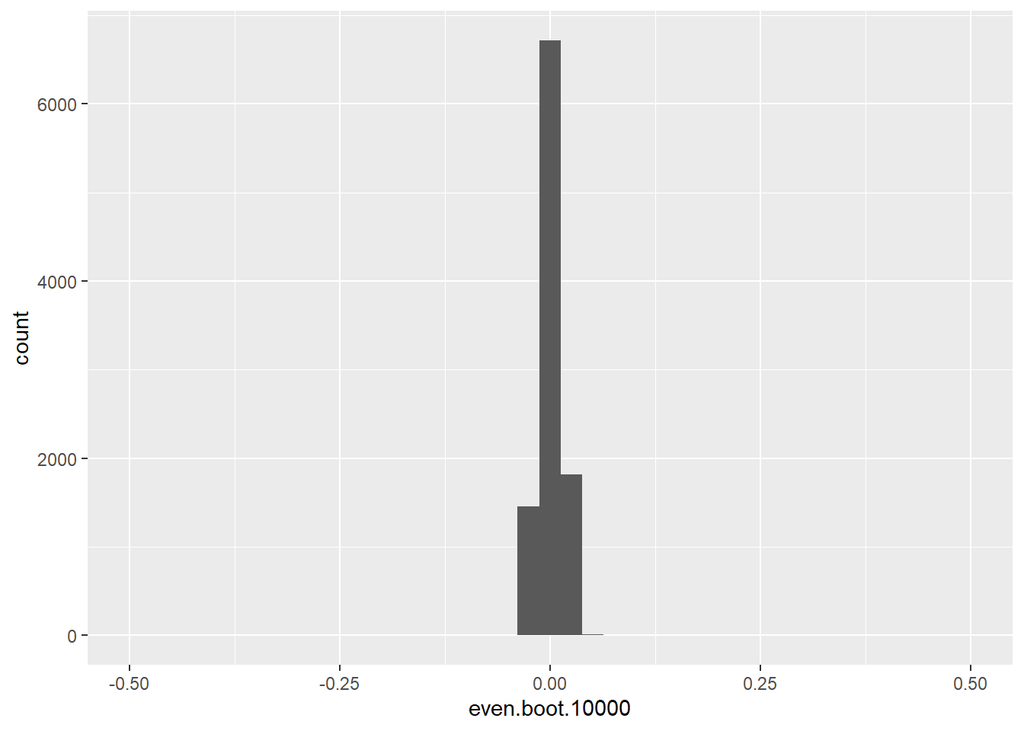

```r
ne <- 10000 # n even
no <- 10001 # n odd
wwe <- rnorm(ne) # draw random sample of size ne
wwo <- rnorm(no) # draw random sample of size no
N <- 10^4
even.boot.10000 <- numeric(N) # save space
odd.boot.10001 <- numeric(N)
for (i in 1:N)
{
x.even <- sample(wwe, ne, replace = TRUE)
x.odd <- sample(wwo, no, replace = TRUE)
even.boot.10000[i] <- median(x.even)
odd.boot.10001[i] <- median(x.odd)
}

par(mfrow = c(2,1))
# set figure layout
ggplot(data = tibble(even.boot.10000), mapping = aes(x = even.boot.10000))+
  geom_histogram(bins = 40)+
  xlim(-0.5,0.5)
```

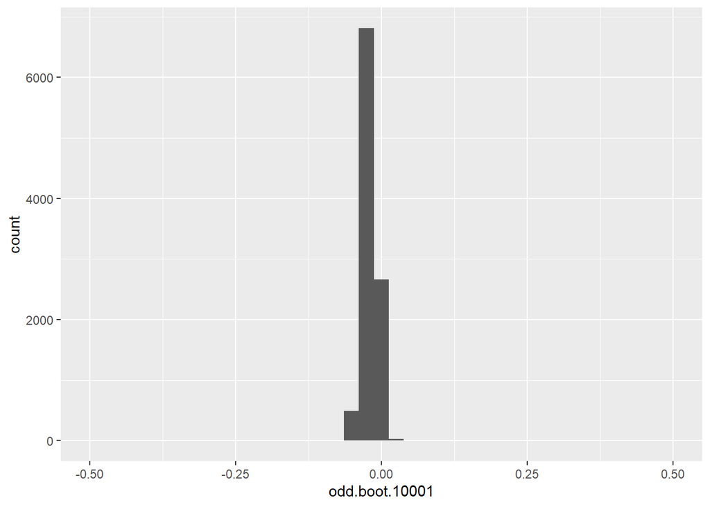

```r
ggplot(data = tibble(odd.boot.10001), mapping = aes(x = odd.boot.10001))+
  geom_histogram(bins = 40)+
  xlim(-0.5,0.5)
```

```r
par(mfrow = c(1,1))
```

AS the n increases, the even and odd both have less variation within their value and are concentrated near 0. Odd still seems to have less spread in their count median and is less granular, but the differences between odd and even decrease when n increases.

```r
median.even.10000 <- median(even.boot.10000)
std.even.10000<- sd(even.boot.10000)
median.odd.10001 <- median(odd.boot.10001)
std.odd.100001 <- sd(odd.boot.10001)
```

## Question 5.14

```r
data <- (Beerwings)

wings.Female <- Beerwings$Hotwings[Beerwings$Gender =="F"]
wings.male <- Beerwings$Hotwings[Beerwings$Gender =="M"]

mean.wings.diff =abs( mean(wings.Female)-mean(wings.male))
mean.wings.diff
```

```
## [1] 5.2
```

```r
set.seed(10000)
N <- 10^4
diff.wings.mean <- numeric(N)

for (i in 1:N)
{
  female.wings <- sample(wings.Female, length(wings.Female), replace = TRUE)
  male.wings <- sample(wings.male, length(wings.male), replace = TRUE)
  diff.wings.mean[i] <- abs(mean(female.wings) - mean(male.wings))
}
```

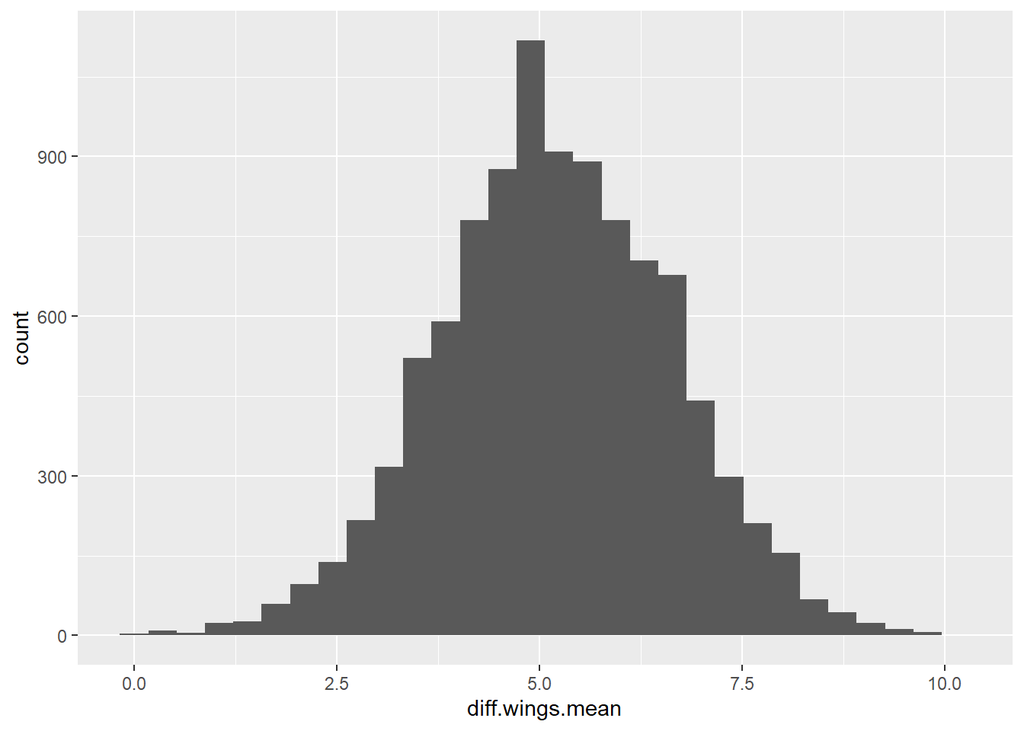

```r
ggplot(data = tibble(diff.wings.mean), mapping = aes(x = diff.wings.mean))+
  geom_histogram()
```

```r
d_means = abs(mean(diff.wings.mean))
d_means
```

```
## [1] 5.19366
```

```r
sd_wings = sd(diff.wings.mean)
sd_wings
```

```
## [1] 1.422491
```

```r
# Calculating the confidence interval through the qunatile method
quantile(diff.wings.mean, c(0.025, 0.975))
```

```
##  2.5% 97.5%
## 2.400 7.935
```

So the values for the confidence interval are 2.40 and 7.935. This means that based on our bootstrap, we can say with 95% confidence that the difference in mean wings eaten between two gender lies within the range of 2.40 and 7.935.

Permutation: we are doing hypothesis testing to test if the difference we observed was purely out of chance or not and to see if the observed difference indicates a systematic difference. . So, for this test, we take samples and divide them into two groups regardless of the gender and compare it with the original observed difference to see if we can statistically conclude that mean on average eat more wings than female. WE test this by creating a permutation testing.

In bootstrap, we take the one sample and test the difference in wings while considering the gender. Since the replacement is true, we cna take several samples from our existing sample to create a bootstrap sample distribution. Through this, we can testing if we say with what level of confidence does our sample represents the value of the parameter.

## 5.19

```r
data.icecream <- IceCream

head(data.icecream, 10)
```

```
##             Brand VanillaCalories VanillaFat VanillaSugar ChocolateCalories
## 1  Baskin Robbins             260       16.0         26.0               260
## 2   Ben & Jerry's             240       16.0         19.0               260
## 3      Blue Bunny             140        7.0         12.0               130
## 4         Breyers             140        7.0         13.0               140
## 5       Brigham's             190       12.0         17.0               200
## 6           Bulla             234       13.5         21.8               266
## 7          Carvel             240       14.0         21.0               250
## 8       Cass-Clay             130        7.0         11.0               150
## 9       Chapman's             120        6.0         11.0               120
## 10     Cold Stone             270       15.5         23.0               264
##    ChocolateFat ChocolateSugar
## 1          14.0           31.0
## 2          16.0           22.0
## 3           7.0           14.0
## 4           8.0           16.0
## 5          12.0           18.0
## 6          15.0           22.6
## 7          13.0           25.0
## 8           7.0           16.0
## 9           5.0           12.0
## 10         16.2           23.6
```

```r
calories.vanilla <- data.icecream$VanillaCalories
calories.chocolate <- data.icecream$ChocolateCalories

meandifference.calories = abs(mean(calories.vanilla) - mean(calories.chocolate))
meandifference.calories
```

```
## [1] 7.333333
```

```r
summary (calories.vanilla)
```

```
##    Min. 1st Qu.  Median    Mean 3rd Qu.    Max.
##   120.0   140.0   160.0   191.4   240.0   307.0
```

```r
summary(calories.chocolate)
```

```
##    Min. 1st Qu.  Median    Mean 3rd Qu.    Max.
##   120.0   140.0   170.0   198.7   260.0   320.0
```

So the calculated difference in calories is 7.33. From the summary statistics, the maximum calorie is high in chocolate and the median and mean is high in chocolate as well.

```r
nvanilla <- length(calories.vanilla)
nchocolate <- length(calories.chocolate)

calories_difference <- data.icecream$ChocolateCalories - data.icecream$VanillaCalories

N <- 10^4

difference.calories <- numeric(N)

for (i in 1:N)
{
 a = sample(calories_difference , size = length(calories_difference), replace = TRUE)
 difference.calories[i] = mean(a)
}
```

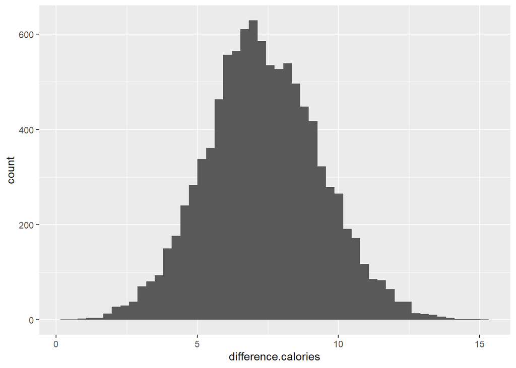

```r
ggplot(data = tibble(difference.calories), mapping = aes(x = difference.calories))+
  geom_histogram(bins = 50 )
```

```r
mean.bootstrapcalorie <- mean(difference.calories)
sd.bootstrapcalorie <- sd(difference.calories)

quantile(difference.calories, c(0.025, 0.975))
```

```
##      2.5%     97.5%
##  3.435256 11.461538
```

We can conclude that the mean calorie difference differ by 3.43 to 11.46 calories between the flavors with 95% confidence level. Since both range is in positive, we can say with confidence that there is a calorie differences between vanilla and chocolate flavor.